# Forecasting # of visitors from Macao

### CMV

```r
source("source.R")
TS_SE1 <- read.csv("macao.csv")
Visitors <- TS_SE1$Macao
Quarter <- TS_SE1$Month
Season <- max(Quarter)
Period <- TS_SE1$period
t  = Period -1
n <- length(Visitors)
CMV_SI <- Center_Moving_Average(Visitors, Quarter, Season)
cat("# # # # The Centered moving average seasonal index # # # ","\n")
```

```
# # # # The Centered moving average seasonal index # # #
```

```r
print(CMV_SI)
```

```
 [1] 0.5386777 1.0865124 0.7624538 0.8355875 0.7428352 1.2570464 1.1507426 1.7271436 1.0598357
[10] 0.7084108 0.7045282 1.4262260
```

### Forecast by seasonal index

```
### Linear Model ###
Call:
lm(formula = Des_x ~ t)

Residuals:
    Min      1Q  Median      3Q     Max
-3101.3  -736.1   -84.4   883.4  3767.3

Coefficients:
            Estimate Std. Error t value Pr(>|t|)
(Intercept) 3168.808    245.332   12.92   <2e-16 ***
t            104.746      3.962   26.44   <2e-16 ***
---
Signif. codes:  0 ‘***’ 0.001 ‘**’ 0.01 ‘*’ 0.05 ‘.’ 0.1 ‘ ’ 1

Residual standard error: 1284 on 106 degrees of freedom
Multiple R-squared:  0.8683,    Adjusted R-squared:  0.8671
F-statistic: 698.9 on 1 and 106 DF,  p-value: < 2.2e-16


    Shapiro-Wilk normality test

data:  Standard_E
W = 0.98453, p-value = 0.2454

run test:[1] 0.6989698
The Outliers[1]  71  81  84  87  96  98 101
influential observations:[1] "no influential observations"
mean_y: 8772.741



deseasonalized data:
  [1]  3238.942  4211.460  3155.354  4059.882  5682.956  4176.955  4025.389  4016.194  3061.200
 [10]  5859.114  3588.414  4206.621  3691.263  5413.484  3509.038  4147.889  5398.950  5033.802
 [19]  4723.729  4403.229  6148.389  5378.678  4367.478  5943.124  5221.885  6684.718  4801.247
 [28]  5662.529  6336.831  4878.525  5813.820  5185.013  4544.461  6419.623  7159.778  4505.812
 [37]  6818.471  7138.161  5630.277  6456.904  7074.681  6542.813  6827.264  7613.800  7399.601
 [46]  7447.683  6355.795  9250.976  8735.450  8364.051  8232.944  8976.092  8174.852  8678.580
 [55]  7986.905  8875.171  8700.935  8691.111  9331.713 10554.251 10477.425  9216.048 10946.844
 [64] 11326.215 10184.597 11146.074  9925.792 11775.132 10906.336 10607.334 14268.405  9625.563
 [73] 11655.344 10092.706 13146.293 11912.154 10605.417 12516.748 12800.056 12472.076 14760.217
 [82]  9693.401 11140.347 15477.733 11415.722 10131.687 14979.023 12240.441 11937.699 13252.197
 [91] 14680.747 13610.045 14043.647 11192.693 15160.262 10537.496 12574.794 10227.944 13854.532
[100] 11873.361 10942.262 12036.801 14506.162 12645.962 13952.684 12047.723 13018.493 15401.140
```

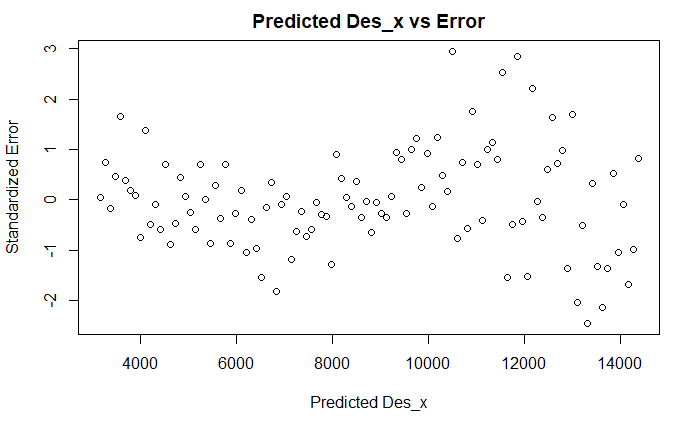

```r
Forecast_Visitors_CMV= Forecast_by_SI(Visitors, Quarter, Season, CMV_SI, t)
```

```r
cat("# # # # The Forecast_Visitors_y # # # ","\n")
```

```
# # # # The Forecast_Visitors_y # # #
```

```r
print(Forecast_Visitors_CMV)
```

```
  [1]  2353.902  4115.009  3887.554  6015.722  3802.472  2615.835  2675.295  5565.180  2158.363
 [10]  4467.223  3214.713  3610.589  3287.614  5695.062  5333.988  8186.667  5134.640  3506.277
 [19]  3560.857  7357.885  2835.457  5832.923  4173.084  4660.886  4221.326  7275.116  6780.422
 [28] 10357.613  6466.808  4396.719  4446.418  9150.590  3512.552  7198.622  5131.456  5711.184
 [37]  5155.038  8855.169  8226.856 12528.558  7798.976  5287.161  5331.980 10943.295  4189.647
 [46]  8564.321  6089.828  6761.481  6088.750 10435.222  9673.290 14699.503  9131.143  6177.603
 [55]  6217.542 12736.000  4866.742  9930.021  7048.199  7811.779  7022.462 12015.276 11119.724
 [64] 16870.448 10463.311  7068.045  7103.103 14528.705  5543.836 11295.720  8006.571  8862.077
 [73]  7956.173 13595.329 12566.158 19041.394 11795.479  7958.487  7988.665 16321.409  6220.931
 [82] 12661.419  8964.943  9912.374  8889.885 15175.382 14012.592 21212.339 13127.647  8848.929
 [91]  8874.227 18114.114  6898.026 14027.119  9923.315 10962.672  9823.597 16755.436 15459.026
[100] 23383.284 14459.815  9739.371  9759.788 19906.819  7575.121 15392.818 10881.686 12012.969
[109]  7800.819 15848.051 11201.144 12363.068 11068.547 18862.173 17387.605 26277.878 16236.039
[118] 10926.627 10940.537 22297.092
```

```r
#write.csv(Forecast_Visitors_CMV,"../../temp.csv")
t2 = c(t,n,n+1,n+2,n+3,n+4,n+5,n+6,n+7,n+8,n+9,n+10,n+11)
lines(t,Visitors, col = "blue", main = "Visitorsagainst Period", xlab = "Period", ylab = "Tourists")
lines(t, Visitors, type="o", col = "blue")    #actual
```

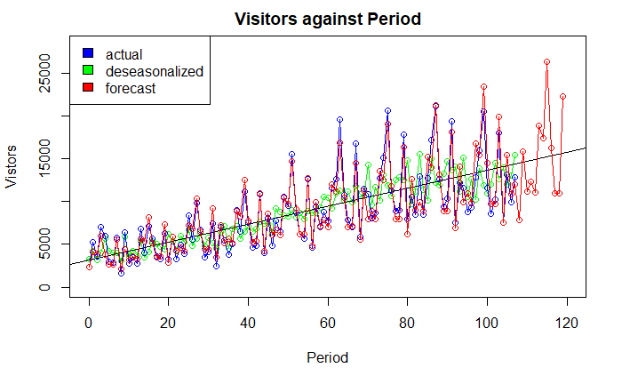

```r
lines(t2,Forecast_Visitors_CMV, type="o", col = "red")  #forecast
legend("topleft", c("actual", "deseasonalized", "forecast"), fill=c("blue","green", "red"))
```

*Residual analysis:*  
1.normality test  
H0: Errors are normally distributed.  
H1: Errors are not normally distributed.  
Since pvalue = 0.2454 > 0.05, we do not reject H0.

3.Dependence of the Error Variable  
H0 : Randomness exists.  
H1 : Randomness does not exist.  
Since pvalue = 0.6989698 > 0.05, we do not reject H0.

*Assessment*  
The standard error of estimate (1284) is large compared to mean_y (8772.741), indicating a weak linear relationship.

r^2 = 86.83 of the variation in the fund value is explained by the variation in Des_x. The rest(13.17%) remains unexplained by this model.

Testing the coefficients beta1.  
H0: beta1 = 0, H1: beta1 != 0  
Since p-value <2e-16 , we are 95% confident to reject H0. There is overwhelming evidence that t affects Des_x.

The # of visitors forecast for the next 12 months will be 7800.82, 15848.05, 11201.14, 12363.07, 11068.55, 18862.17, 17387.61, 26277.88, 16236.04, 10926.63, 10940.54, 22297.09 respectively.

## Smoothing by Linear Regression Model

```r
SLR_SI <- Linear_Regression_Seasonal_Index(Visitors, Quarter, Season)
cat("# # # # The Simple Linear_Regression seasonal index # # # ","\n")
```

```
# # # # The Simple Linear_Regression seasonal index # # #
```

```r
print(SLR_SI)
```

```
 [1] 0.5389160 1.0689415 0.7580519 0.8449363 0.7325939 1.2675340 1.1331444 1.7295181 1.0992645
[10] 0.7054126 0.7088145 1.4128723
```

### Forecast by seasonal index

```
### Linear Model ###
Call:
lm(formula = Des_x ~ t)

Residuals:
    Min      1Q  Median      3Q     Max
-3193.4  -806.9   -51.6   842.3  3846.2

Coefficients:
            Estimate Std. Error t value Pr(>|t|)
(Intercept) 3163.558    248.214   12.74   <2e-16 ***
t            104.878      4.009   26.16   <2e-16 ***
---
Signif. codes:  0 ‘***’ 0.001 ‘**’ 0.01 ‘*’ 0.05 ‘.’ 0.1 ‘ ’ 1

Residual standard error: 1299 on 106 degrees of freedom
Multiple R-squared:  0.8659,    Adjusted R-squared:  0.8646
F-statistic: 684.5 on 1 and 106 DF,  p-value: < 2.2e-16


    Shapiro-Wilk normality test

data:  Standard_E
W = 0.98464, p-value = 0.2504

run test:[1] 0.6989698
The Outliers[1]  71  81  84  87  96  98 101
influential observations:[1] "no influential observations"
mean_y: 8774.535



deseasonalized data:
  [1]  3284.221  4176.614  3204.358  4054.308  5479.118  4194.708  4001.047  4054.153  3059.846
 [10]  5955.424  3609.252  4160.077  3742.865  5368.692  3563.535  4142.194  5205.299  5055.197
 [19]  4695.163  4444.846  6145.670  5467.091  4392.839  5877.366  5294.885  6629.408  4875.813
 [28]  5654.754  6109.540  4899.260  5778.663  5234.019  4542.452  6525.147  7201.354  4455.957
 [37]  6913.790  7079.100  5717.718  6448.039  6820.925  6570.622  6785.978  7685.762  7396.329
 [46]  7570.106  6392.702  9148.619  8857.568  8294.847  8360.805  8963.768  7881.634  8715.466
 [55]  7938.607  8959.055  8697.088  8833.973  9385.901 10437.473 10623.895  9139.794 11116.853
 [64] 11310.665  9819.293 11193.449  9865.769 11886.425 10901.514 10781.694 14351.261  9519.061
 [73] 11818.281 10009.199 13350.460 11895.799 10225.019 12569.948 12722.651 12589.956 14753.691
 [82]  9852.738 11205.038 15306.480 11575.309 10047.857 15211.653 12223.636 11509.514 13308.523
 [91] 14591.970 13738.680 14037.438 11376.675 15248.297 10420.904 12750.585 10143.318 14069.698
[100] 11857.060 10549.782 12087.960 14418.441 12765.485 13946.515 12245.759 13094.091 15230.734
```

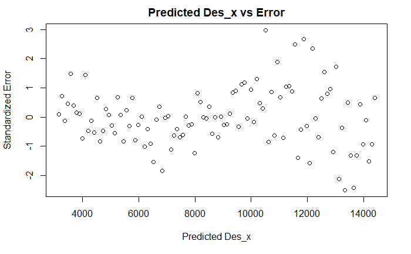

```r
Forecast_Visitors_SLR <- Forecast_by_SI(Visitors, Quarter, Season, SLR_SI, t)
```

```r
cat("# # # # The Forecast_Visitors_y # # # ","\n")
```

```
# # # # The Forecast_Visitors_y # # #
```

```r
print(Forecast_Visitors_SLR)
```

```
  [1]  2317.603  4142.854  3822.452  6015.596  3938.742  2601.525  2688.410  5506.959  2157.056
 [10]  4390.635  3193.171  3647.773  3239.600  5738.092  5248.556  8192.259  5322.207  3489.313
 [19]  3580.480  7285.111  2835.301  5735.938  4147.208  4711.157  4161.596  7333.331  6674.660
 [28] 10368.922  6705.672  4377.101  4472.549  9063.263  3513.547  7081.240  5101.244  5774.540
 [37]  5083.593  8928.569  8100.765 12545.584  8089.137  5264.889  5364.618 10841.415  4191.793
 [46]  8426.542  6055.280  6837.924  6005.589 10523.808  9526.869 14722.247  9472.602  6152.677
 [55]  6256.688 12619.567  4870.039  9771.845  7009.317  7901.307  6927.585 12119.046 10952.973
 [64] 16898.909 10856.067  7040.465  7148.757 14397.719  5548.284 11117.147  7963.353  8964.691
 [73]  7849.582 13714.284 12379.077 19075.572 12239.532  7928.253  8040.826 16175.871  6226.530
 [82] 12462.450  8917.389 10028.075  8771.578 15309.523 13805.182 21252.235 13622.997  8816.041
 [91]  8932.896 17954.023  6904.776 13807.752  9871.426 11091.458  9693.575 16904.761 15231.286
[100] 23428.897 15006.462  9703.829  9824.965 19732.175  7583.022 15153.054 10825.462 12154.842
[109]  7809.103 15601.489 11143.474 12509.303 10922.904 19031.746 17132.758 26331.114 16851.082
[118] 10887.546 11014.391 22103.045
```

```r
lines(t, Visitors, type="o", col = "blue")    #actual
lines(t2,Forecast_Visitors_SLR, type="o", col = "red")  #forecast
```

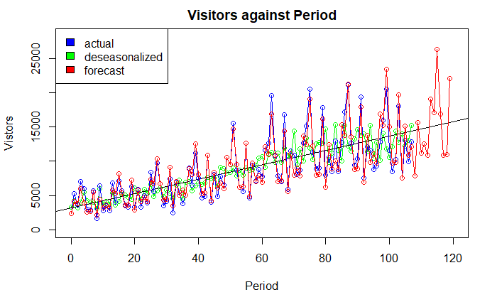

```r
legend("topleft", c("actual", "deseasonalized", "forecast"), fill=c("blue","green", "red"))
```

*Residual analysis:*  
1.normality test  
H0: Errors are normally distributed.  
H1: Errors are not normally distributed.  
Since pvalue = 0.2504 > 0.05, we do not reject H0.

3.Dependence of the Error Variable  
H0 : Randomness exists.  
H1 : Randomness does not exist.  
Since pvalue = 0.6989698 > 0.05, we do not reject H0.

*Assessment*  
The standard error of estimate (1299) is large compared to mean_y (8774.535), indicating a weak linear relationship.

r^2 = 86.59 of the variation in the fund value is explained by the variation in Des_x. The rest(13.41%) remains unexplained by this model.

Testing the coefficients beta1.  
H0: beta1 = 0, H1: beta1 != 0  
Since p-value <2e-16 , we are 95% confident to reject H0. There is overwhelming evidence that t affects Des_x.

The # of visitors forecast for the next 12 months will be 7809.103, 15601.489, 11143.474, 12509.303, 10922.904, 19031.746, 17132.758, 26331.114, 16851.082, 10887.546, 11014.391, 22103.045 respectively.

## Regression model by indicator variables

### The Regression Model

y = beta0 + beta1*t + beta2*Q1 + beta3*Q2 + beta4*Q3 + beta5*Q4 +beta6*Q5 +beta7*Q6 +beta8*Q7 +beta*9Q8 +beta10*Q9 +beta11*Q10 +vbeta12Q*11 +e where t = time in chronological order Qi = indicator variable (0, 1).

### Dummy as Quarter

```r
Dummy_I <- Season - 1    # n-1 indicator variables
Q <- matrix(nrow =n, ncol = Dummy_I)
Dummy_Name <- vector("character", length = Dummy_I)
for(i in 1:Dummy_I){
  Dummy_Name[i] <- paste0("Q", i)
}
colnames(Q) <- Dummy_Name
for(i in 1:n){
  for(j in 1:Dummy_I){
    if(Quarter[i] == j){
      Q[i,j] <- 1
    } else {
      Q[i,j] <- 0
    }
  }
}
```

### build the model

```r
Data.Visitors <- cbind(t, Q)  #t, Q1, Q2, Q3...
linearModelVar1 <- lm(Visitors ~ Data.Visitors)
cat("\n# # # # The regression model # # # ","\n")
```

```
# # # # The regression model # # #
```

```r
print(summary(linearModelVar1))
```

```
Call:
lm(formula = Visitors ~ Data.Visitors)

Residuals:
    Min      1Q  Median      3Q     Max
-3869.9  -954.7   180.6   740.0  3625.9

Coefficients:
                 Estimate Std. Error t value Pr(>|t|)
(Intercept)       7155.07     606.66  11.794  < 2e-16 ***
Data.Visitorst     102.13       5.03  20.303  < 2e-16 ***
Data.VisitorsQ1  -7875.46     763.55 -10.314  < 2e-16 ***
Data.VisitorsQ2  -3639.92     763.60  -4.767 6.73e-06 ***
Data.VisitorsQ3  -5929.16     763.68  -7.764 9.43e-12 ***
Data.VisitorsQ4  -5242.29     763.80  -6.863 6.85e-10 ***
Data.VisitorsQ5  -5963.55     764.34  -7.802 7.84e-12 ***
Data.VisitorsQ6  -2175.57     764.13  -2.847  0.00541 **
Data.VisitorsQ7  -2255.69     763.95  -2.953  0.00397 **
Data.VisitorsQ8   2346.96     763.80   3.073  0.00277 **
Data.VisitorsQ9  -3476.17     763.68  -4.552 1.57e-05 ***
Data.VisitorsQ10 -6407.63     763.60  -8.391 4.48e-13 ***
Data.VisitorsQ11 -6306.54     763.55  -8.260 8.52e-13 ***
---
Signif. codes:  0 ‘***’ 0.001 ‘**’ 0.01 ‘*’ 0.05 ‘.’ 0.1 ‘ ’ 1

Residual standard error: 1620 on 95 degrees of freedom
Multiple R-squared:  0.8845,    Adjusted R-squared:  0.8699
F-statistic: 60.63 on 12 and 95 DF,  p-value: < 2.2e-16
```

```r
cat(" ","\n")
```

```r
ANOVA_T_lm <- anova(linearModelVar1)
cat("# # # # The ANOVA Table # # # ","\n")
```

```
# # # # The ANOVA Table # # #
```

```r
print(ANOVA_T_lm)
```

```
Analysis of Variance Table

Response: Visitors
              Df     Sum Sq   Mean Sq F value    Pr(>F)
Data.Visitors 12 1908826482 159068873  60.634 < 2.2e-16 ***
Residuals     95  249223991   2623410
---
Signif. codes:  0 ‘***’ 0.001 ‘**’ 0.01 ‘*’ 0.05 ‘.’ 0.1 ‘ ’ 1
```

```r
#residual analysis
SE_1 <- standarized_errors_MR(Visitors, Data.Visitors)[,1]
h_1 <- standarized_errors_MR(Visitors, Data.Visitors)[,2]
D_1 <- standarized_errors_MR(Visitors, Data.Visitors)[,3]
print(shapiro.test(SE_1) )          # normality
```

```
    Shapiro-Wilk normality test

data:  SE_1
W = 0.97543, p-value = 0.04282
```

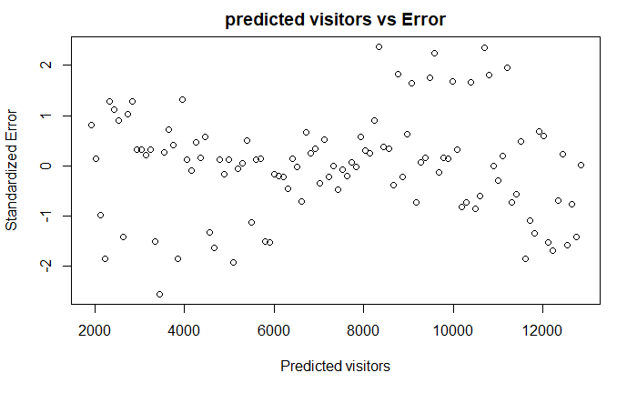

```r
b0<- coef(linearModelVar1)[1]             # Homoscedasticity & Heteroscedasticity
b1 <- coef(linearModelVar1)[2]
b2 <- coef(linearModelVar1)[3]
b3 <- coef(linearModelVar1)[4]
b4 <- coef(linearModelVar1)[5]
b5 <- coef(linearModelVar1)[6]
b6 <- coef(linearModelVar1)[7]
b7 <- coef(linearModelVar1)[8]
b8 <- coef(linearModelVar1)[9]
b9 <- coef(linearModelVar1)[10]
b10 <- coef(linearModelVar1)[11]
b11 <- coef(linearModelVar1)[12]
b12 <- coef(linearModelVar1)[13]
yhat <- vector("double", length = n)
for(i in 1:n) {
       yhat <- b0 + b1 *t + b2 *Q[i,1] + b3 *Q[i,2] + b4 *Q[i,3]+ b5 *Q[i,4]+ b6 *Q[i,5]+ b7 *Q[i,6]+ b8 *Q[i,7]+ b9 *Q[i,8]+ b10 *Q[i,9]+ b11 *Q[i,10]+ b12 *Q[i,11]
}
plot(x = yhat, y = SE_1, xlab = "Predicted visitors", ylab = "Standardized Error", main = "predicted visitors vs Error")
```

```r
cat("\nRun_Test:\n")
```

```
Run_Test:
```

```r
print(Run_Test(SE_1))              #errors are independent
```

```
[1] 0.08182361
```

```r
cat("\nThe Outliers\n")
```

```
The Outliers
```

```r
Outliers <- abs(SE_1) > 2
if(sum(Outliers)!=0){
    print(which(Outliers))
}else{
  print("no outliers")
}
```

```
[1] 16 64 76 87
```

```r
cat("\ninfluential observations:\n")
```

```
influential observations:
```

```r
k <- dim(Data.Visitors)[2]
Inf_Obs <- h_1 > 3*(k+1)/n
if(sum(Inf_Obs)!=0){
    print(which(Inf_Obs))
}else{
  print("no influential observations")
}
```

```
[1] "no influential observations"
```

```r
#assesment
cat("\nmean_y:",mean(Visitors),"\n")
```

```
mean_y: 8708.5
```

*Residual analysis:*  
normality test  
H0: Errors are normally distributed.  
H1: Errors are not normally distributed.  
Since pvalue = 0.04282 < 0.05, we reject H0. Therefore we do not use this method to forecast the # of visitors from Macao.

## Error Metrics

```r
CMV_MAD <- Mean_Absolute_Deviation(Visitors, Forecast_Visitors_CMV, 1)  #actual y, predicted y
CMV_MSE <- Mean_Square_Error(Visitors, Forecast_Visitors_CMV, 1)
CMV_MAPE <- Mean_Absolute_Percentage_Error(Visitors, Forecast_Visitors_CMV, 1)
SLR_MAD <- Mean_Absolute_Deviation(Visitors, Forecast_Visitors_SLR, 1)
SLR_MSE <- Mean_Square_Error(Visitors, Forecast_Visitors_SLR, 1)
SLR_MAPE <- Mean_Absolute_Percentage_Error(Visitors, Forecast_Visitors_SLR, 1)
Error_M <- matrix(nrow = 3, ncol = 2)
colnames(Error_M) = c("CMV", "SLR")
rownames(Error_M) = c("MAD", "MSE", "MAPE")
Error_M[1,1] <- CMV_MAD
Error_M[1,2] <- SLR_MAD
Error_M[2,1] <- CMV_MSE
Error_M[2,2] <- SLR_MSE
Error_M[3,1] <- CMV_MAPE
Error_M[3,2] <- SLR_MAPE
cat("\n# # # # Error Metrix # # # ","\n")
```

```
# # # # Error Metrix # # #
```

```r
print(Error_M)
```

```
              CMV          SLR
MAD  9.535612e+02 9.616170e+02
MSE  1.623418e+06 1.683360e+06
MAPE 1.180574e+01 1.177422e+01
```

MAD: CMV is smaller by 8  
MSE: CMV is smaller by 59942 MAPE: SLR is smaller by 0.03

## Therefore, we choose CMV as the best method to forecast the # of visitors from Macao for the next 12 momnths.

## Conclusion:

By CMV, we forecast that the number of visitors from Macao for the next 12 months will be 7800.82, 15848.05, 11201.14, 12363.07, 11068.55, 18862.17, 17387.61, 26277.88, 16236.04, 10926.63, 10940.54, 22297.09 respectively.